# Healthcare Facilities and Risk Factors

Nathan Seto

2025-04-24

## What is the relationship between health risk concentrations and healthcare market supply?

#### (Goal is to ultimately assess health care supply-side institutional capacities and possible gaps)

##### First pass: calculate correlations between environmental risk variables and health care services/infrastructure (particularly for data series identified as targeting “migrant” health) but others too

## Exploration

Counts of health facilities labeled as migrant health centers, according to the [National Center for Farmworker Health](https://public.tableau.com/app/profile/national.center.for.farmworker.health/viz/MigrantHealthCentersUDS2023/Dashboard1) (2023).

An option to export the data to a .csv was not found, so a data set was manually created by investigating each point within the HICAHS states. During the creation of the .csv used in my analysis, some facilities were found to be permanently closed. They have subsequently been excluded from the file.

It must be kept in mind that some facilities in this list are mobile vans or seasonal locations, and three are purely administrative buildings.

Given current knowledge, Wyoming and South Dakota have no facilities labeled as migrant health centers. $\\$

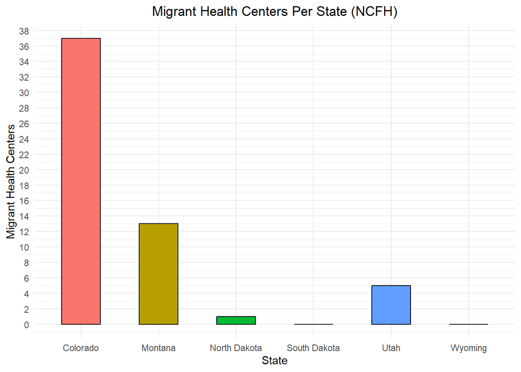

[interactive chart not shown]

# Correlations

*All correlations coefficients have been calculated with the ‘cor.test()’ function.* *Tables are sorted by correlation coefficient in descending order.*

### Correlations Between the Total Number of H-2A workers and Healthcare Facilities.

$\\$

Each state has different sets of health facility data, where some states have more or less recorded types of facilities. Utah especially has many more categories of healthcare facilities than any other state. I could remove those differing variables, but then the only facility type in common would be hospitals, and I don’t want to limit the data to a single type. When calculating correlations, I separated data by state, then aggregated all the data sets after calculating the coefficients. Only one correlation with Total H2A Workers was found to be not significant: Critical Access Hospitals in South Dakota. It appears that Utah has the greatest correlation between the number of H-2A workers and health facilities.

For each of these correlation coefficients, it could be reasoned that the H-2A population is correlated with higher state/county population, which may also be correlated with an increased number of healthcare facilities, making state or local population a confounder. Further analysis is necessary.

Correlations between H-2A population numbers and healthcare facilities:

| State | Variable | Predictor | Correlation | PValue | Significance |
| --- | --- | --- | --- | --- | --- |
| Utah | H2Aworkers | Mammography | 0.690 | 0.00 | TRUE |
| Utah | H2Aworkers | Hospitals | 0.563 | 0.00 | TRUE |
| Utah | H2Aworkers | Assisted Living Facility - Type II | 0.559 | 0.00 | TRUE |
| Colorado | H2Aworkers | Hospitals | 0.472 | 0.00 | TRUE |
| Utah | H2Aworkers | Home Health Agency | 0.468 | 0.00 | TRUE |
| Utah | H2Aworkers | Personal Care Agency | 0.464 | 0.00 | TRUE |
| Utah | H2Aworkers | Nursing Care Facility | 0.447 | 0.00 | TRUE |
| North Dakota | H2Aworkers | Hospitals | 0.435 | 0.00 | TRUE |
| Utah | H2Aworkers | Ambulatory Surgical Facility | 0.405 | 0.00 | TRUE |
| Colorado | H2Aworkers | Free_Standing_Emergency_Departments | 0.361 | 0.00 | TRUE |
| Utah | H2Aworkers | End Stage Renal Disease Facility | 0.332 | 0.00 | TRUE |
| Utah | H2Aworkers | Hospice | 0.301 | 0.00 | TRUE |
| North Dakota | H2Aworkers | Rural_Health_Clinics | 0.284 | 0.00 | TRUE |
| Colorado | H2Aworkers | Rehabilitation_Hospitals | 0.283 | 0.00 | TRUE |
| Wyoming | H2Aworkers | Critical_Access_Hospitals | 0.259 | 0.00 | TRUE |
| Utah | H2Aworkers | Assisted Living Facility - Type I | 0.239 | 0.00 | TRUE |
| Montana | H2Aworkers | Hospitals | 0.223 | 0.00 | TRUE |
| Montana | H2Aworkers | Rural_Clinics | 0.203 | 0.00 | TRUE |
| Utah | H2Aworkers | Abortion Clinic | 0.199 | 0.00 | TRUE |
| Wyoming | H2Aworkers | Hospitals | 0.165 | 0.00 | TRUE |
| South Dakota | H2Aworkers | Hospitals | 0.077 | 0.00 | TRUE |
| Wyoming | H2Aworkers | Rural_Health_Clinics | 0.067 | 0.01 | TRUE |
| South Dakota | H2Aworkers | Critical Access Hospitals | -0.012 | 0.52 | FALSE |
| South Dakota | H2Aworkers | Rural Health Clinics | -0.044 | 0.01 | TRUE |
| Colorado | H2Aworkers | Community_Clinics | -0.219 | 0.00 | TRUE |

### Correlations Between Environmental Factors and Healthcare Facilities.

The following correlations have been adjusted to a per capita context.

$\\$

Most correlations are not currently statistically significant– Colorado has the highest proportion of significance of all six states.

I believe the decision to build healthcare facilities is not based around frequency of natural disasters or negative weather. For example, in Colorado Springs (El Paso county), a new UCHealth facility and a new hospital have recently been built in a heavily populated area. Winter weather frequently occurs in Colorado in general, which would explain any substantial correlations between those types of variables and healthcare facilities.

Natural disasters that had zero events have been excluded. These variables are those pertaining to wildfires, earthquakes, coastal flooding, tsunamis, volcanic activity, and hurricanes. All of these variables have been left empty by FEMA. While I do not agree with removing wildfires, it is unwise to perform correlation between a natural disaster and a response variable if, according to the data, the natural disaster in question never occurred during the time period the data pertains to. Predictor variables not specifically pertaining to natural disasters have also been excluded, as they are not variables in question.

As seen in previous analyses, many correlations have a p-value equal to or very close to zero.

One explanation for negative correlations would be that the given healthcare facilities are not in proximity of the natural disasters. More events of the natural disaster happen far away from the health facilities.

### Colorado:

In 2023, Colorado saw the highest number of tornadoes reported per year and reported on a single day.

```
## Number of Correlations Statistically Signifcant: 292
```

```
## Percentage: 34.56 %
```

```
## Number of Correlations Not Statistically Signifcant: 553
```

```
## Percentage: 65.44 %
```

| Predictor | Response | Correlation | PValue | Sig |
| --- | --- | --- | --- | --- |
| HailExpectedAnnualLossPopulation | FreeStandingEmergencyDepartments PerCapita | 0.642 | 0.000 | TRUE |
| TornadoExpectedAnnualLossPopulation | FreeStandingEmergencyDepartments PerCapita | 0.605 | 0.000 | TRUE |
| ColdWaveExposureBuildingValue | FreeStandingEmergencyDepartments PerCapita | 0.601 | 0.000 | TRUE |
| ColdWaveExposurePopulation | FreeStandingEmergencyDepartments PerCapita | 0.601 | 0.000 | TRUE |
| ColdWaveExposureTotal | FreeStandingEmergencyDepartments PerCapita | 0.601 | 0.000 | TRUE |
| TornadoExpectedAnnualLossTotal | FreeStandingEmergencyDepartments PerCapita | 0.601 | 0.000 | TRUE |
| TornadoExpectedAnnualLossScore | FreeStandingEmergencyDepartments PerCapita | 0.601 | 0.000 | TRUE |
| TornadoHazardTypeRiskIndexValue | FreeStandingEmergencyDepartments PerCapita | 0.601 | 0.000 | TRUE |
| TornadoHazardTypeRiskIndexScore | FreeStandingEmergencyDepartments PerCapita | 0.601 | 0.000 | TRUE |
| HailExpectedAnnualLossPopulation | RehabilitationHospitals PerCapita | 0.601 | 0.000 | TRUE |
| HailExposureBuildingValue | FreeStandingEmergencyDepartments PerCapita | 0.600 | 0.000 | TRUE |
| HailExposurePopulation | FreeStandingEmergencyDepartments PerCapita | 0.600 | 0.000 | TRUE |
| HailExposureTotal | FreeStandingEmergencyDepartments PerCapita | 0.600 | 0.000 | TRUE |
| IceStormExposureBuildingValue | FreeStandingEmergencyDepartments PerCapita | 0.600 | 0.000 | TRUE |
| IceStormExposurePopulation | FreeStandingEmergencyDepartments PerCapita | 0.600 | 0.000 | TRUE |
| IceStormExposureTotal | FreeStandingEmergencyDepartments PerCapita | 0.600 | 0.000 | TRUE |
| LightningExposureBuildingValue | FreeStandingEmergencyDepartments PerCapita | 0.600 | 0.000 | TRUE |
| LightningExposurePopulation | FreeStandingEmergencyDepartments PerCapita | 0.600 | 0.000 | TRUE |
| LightningExposureTotal | FreeStandingEmergencyDepartments PerCapita | 0.600 | 0.000 | TRUE |
| StrongWindExposureBuildingValue | FreeStandingEmergencyDepartments PerCapita | 0.600 | 0.000 | TRUE |
| StrongWindExposurePopulation | FreeStandingEmergencyDepartments PerCapita | 0.600 | 0.000 | TRUE |
| StrongWindExposureTotal | FreeStandingEmergencyDepartments PerCapita | 0.600 | 0.000 | TRUE |
| TornadoExposureBuildingValue | FreeStandingEmergencyDepartments PerCapita | 0.600 | 0.000 | TRUE |
| TornadoExposurePopulation | FreeStandingEmergencyDepartments PerCapita | 0.600 | 0.000 | TRUE |
| TornadoExposureTotal | FreeStandingEmergencyDepartments PerCapita | 0.600 | 0.000 | TRUE |
| TornadoExpectedAnnualLossBuildingValue | FreeStandingEmergencyDepartments PerCapita | 0.600 | 0.000 | TRUE |
| WinterWeatherExposureBuildingValue | FreeStandingEmergencyDepartments PerCapita | 0.600 | 0.000 | TRUE |
| WinterWeatherExposurePopulation | FreeStandingEmergencyDepartments PerCapita | 0.600 | 0.000 | TRUE |
| WinterWeatherExposureTotal | FreeStandingEmergencyDepartments PerCapita | 0.600 | 0.000 | TRUE |
| LightningExpectedAnnualLossTotal | FreeStandingEmergencyDepartments PerCapita | 0.588 | 0.000 | TRUE |

[output cut: 815 more lines]

$\\$

### Wyoming:

```
## Number of Correlations Statistically Signifcant: 151
```

```
## Percentage: 30.88 %
```

```
## Number of Correlations Not Statistically Signifcant: 338
```

```
## Percentage: 69.12 %
```

| Predictor | Response | Correlation | PValue | Sig |
| --- | --- | --- | --- | --- |
| ColdWaveExposureBuildingValue | Hospitals PerCapita | 0.693 | 0.000 | TRUE |
| ColdWaveExposurePopulation | Hospitals PerCapita | 0.690 | 0.000 | TRUE |
| ColdWaveExposureTotal | Hospitals PerCapita | 0.690 | 0.000 | TRUE |
| HailExposurePopulation | Hospitals PerCapita | 0.672 | 0.000 | TRUE |
| HailExposureTotal | Hospitals PerCapita | 0.672 | 0.000 | TRUE |
| IceStormExposurePopulation | Hospitals PerCapita | 0.672 | 0.000 | TRUE |
| IceStormExposureTotal | Hospitals PerCapita | 0.672 | 0.000 | TRUE |
| LightningExposurePopulation | Hospitals PerCapita | 0.672 | 0.000 | TRUE |
| LightningExposureTotal | Hospitals PerCapita | 0.672 | 0.000 | TRUE |
| StrongWindExposurePopulation | Hospitals PerCapita | 0.672 | 0.000 | TRUE |
| StrongWindExposureTotal | Hospitals PerCapita | 0.672 | 0.000 | TRUE |
| TornadoExposurePopulation | Hospitals PerCapita | 0.672 | 0.000 | TRUE |
| TornadoExposureTotal | Hospitals PerCapita | 0.672 | 0.000 | TRUE |
| WinterWeatherExposurePopulation | Hospitals PerCapita | 0.672 | 0.000 | TRUE |
| WinterWeatherExposureTotal | Hospitals PerCapita | 0.672 | 0.000 | TRUE |
| HailExposureBuildingValue | Hospitals PerCapita | 0.659 | 0.001 | TRUE |
| IceStormExposureBuildingValue | Hospitals PerCapita | 0.659 | 0.001 | TRUE |
| LightningExposureBuildingValue | Hospitals PerCapita | 0.659 | 0.001 | TRUE |
| StrongWindExposureBuildingValue | Hospitals PerCapita | 0.659 | 0.001 | TRUE |
| TornadoExposureBuildingValue | Hospitals PerCapita | 0.659 | 0.001 | TRUE |
| WinterWeatherExposureBuildingValue | Hospitals PerCapita | 0.659 | 0.001 | TRUE |
| IceStormHazardTypeRiskIndexValue | Hospitals PerCapita | 0.626 | 0.001 | TRUE |
| IceStormHazardTypeRiskIndexScore | Hospitals PerCapita | 0.626 | 0.001 | TRUE |
| RiverineFloodingExposurePopulation | Hospitals PerCapita | 0.626 | 0.001 | TRUE |
| RiverineFloodingExposureTotal | Hospitals PerCapita | 0.626 | 0.001 | TRUE |
| IceStormExpectedAnnualLossTotal | Hospitals PerCapita | 0.620 | 0.002 | TRUE |
| IceStormExpectedAnnualLossScore | Hospitals PerCapita | 0.620 | 0.002 | TRUE |
| LandslideExposurePopulation | Hospitals PerCapita | 0.618 | 0.002 | TRUE |
| LandslideExposureTotal | Hospitals PerCapita | 0.618 | 0.002 | TRUE |
| RiverineFloodingExposureBuildingValue | Hospitals PerCapita | 0.582 | 0.004 | TRUE |

[output cut: 459 more lines]

$\\$

### Utah:

```
## Number of Correlations Statistically Signifcant: 287
```

```
## Percentage: 17.5 %
```

```
## Number of Correlations Not Statistically Signifcant: 1353
```

```
## Percentage: 82.5 %
```

| Predictor | Response | Correlation | PValue | Sig |
| --- | --- | --- | --- | --- |
| DroughtHazardTypeRiskIndexValue | HomeHealthAgency PerCapita | 0.672 | 0.000 | TRUE |
| DroughtHazardTypeRiskIndexScore | HomeHealthAgency PerCapita | 0.672 | 0.000 | TRUE |
| DroughtExpectedAnnualLossAgricultureValue | HomeHealthAgency PerCapita | 0.660 | 0.000 | TRUE |
| DroughtExpectedAnnualLossTotal | HomeHealthAgency PerCapita | 0.660 | 0.000 | TRUE |
| DroughtExpectedAnnualLossScore | HomeHealthAgency PerCapita | 0.660 | 0.000 | TRUE |
| LandslideAnnualizedFrequency | AssistedLivingFacilityTypeI PerCapita | 0.643 | 0.000 | TRUE |
| DroughtExposureAgricultureValue | HomeHealthAgency PerCapita | 0.629 | 0.000 | TRUE |
| DroughtExposureTotal | HomeHealthAgency PerCapita | 0.629 | 0.000 | TRUE |
| HeatWaveExposureAgricultureValue | HomeHealthAgency PerCapita | 0.616 | 0.000 | TRUE |
| LandslideExpectedAnnualLossPopulation | AssistedLivingFacilityTypeI PerCapita | 0.608 | 0.000 | TRUE |
| LandslideExposureTotal | EndStageRenalDiseaseFacility PerCapita | 0.605 | 0.001 | TRUE |
| LandslideExposurePopulation | EndStageRenalDiseaseFacility PerCapita | 0.597 | 0.001 | TRUE |
| LandslideExpectedAnnualLossTotal | AssistedLivingFacilityTypeI PerCapita | 0.590 | 0.001 | TRUE |
| LandslideExpectedAnnualLossScore | AssistedLivingFacilityTypeI PerCapita | 0.589 | 0.001 | TRUE |
| HeatWaveExpectedAnnualLossAgricultureValue | HomeHealthAgency PerCapita | 0.588 | 0.001 | TRUE |
| IceStormExpectedAnnualLossPopulation | EndStageRenalDiseaseFacility PerCapita | 0.575 | 0.001 | TRUE |
| LandslideExposureImpactedAreasqmi | PersonalCareAgency PerCapita | 0.571 | 0.001 | TRUE |
| RiverineFloodingExposurePopulation | AssistedLivingFacilityTypeII PerCapita | 0.563 | 0.001 | TRUE |
| RiverineFloodingExposureTotal | AssistedLivingFacilityTypeII PerCapita | 0.563 | 0.001 | TRUE |
| LandslideExpectedAnnualLossPopulation | NursingCareFacility PerCapita | 0.562 | 0.002 | TRUE |
| TornadoExposureImpactedAreasqmi | Hospitals PerCapita | 0.560 | 0.002 | TRUE |
| LandslideExpectedAnnualLossPopulation | Hospitals PerCapita | 0.559 | 0.002 | TRUE |
| LandslideHazardTypeRiskIndexValue | AssistedLivingFacilityTypeI PerCapita | 0.558 | 0.002 | TRUE |
| LandslideHazardTypeRiskIndexScore | AssistedLivingFacilityTypeI PerCapita | 0.558 | 0.002 | TRUE |
| ColdWaveExposureImpactedAreasqmi | Hospitals PerCapita | 0.553 | 0.002 | TRUE |
| DroughtExposureImpactedAreasqmi | Hospitals PerCapita | 0.553 | 0.002 | TRUE |
| HailExposureImpactedAreasqmi | Hospitals PerCapita | 0.553 | 0.002 | TRUE |
| HeatWaveExposureImpactedAreasqmi | Hospitals PerCapita | 0.553 | 0.002 | TRUE |
| IceStormExposureImpactedAreasqmi | Hospitals PerCapita | 0.553 | 0.002 | TRUE |
| LightningExposureImpactedAreasqmi | Hospitals PerCapita | 0.553 | 0.002 | TRUE |

[output cut: 1610 more lines]

$\\$

### South Dakota:

The top 4 highest correlation coefficients come from Riverine Flooding. The highest correlations suggest medium-strength correlations at best.

```
## Number of Correlations Statistically Signifcant: 113
```

```
## Percentage: 24.62 %
```

```
## Number of Correlations Not Statistically Signifcant: 346
```

```
## Percentage: 75.38 %
```

| Predictor | Response | Correlation | PValue | Sig |
| --- | --- | --- | --- | --- |
| RiverineFloodingExposurePopulation | Hospitals PerCapita | 0.539 | 0.000 | TRUE |
| RiverineFloodingExposureTotal | Hospitals PerCapita | 0.538 | 0.000 | TRUE |
| RiverineFloodingExpectedAnnualLossPopulation | Hospitals PerCapita | 0.535 | 0.000 | TRUE |
| RiverineFloodingExposureBuildingValue | Hospitals PerCapita | 0.534 | 0.000 | TRUE |
| ColdWaveExposurePopulation | Hospitals PerCapita | 0.531 | 0.000 | TRUE |
| ColdWaveExposureTotal | Hospitals PerCapita | 0.531 | 0.000 | TRUE |
| HailExposurePopulation | Hospitals PerCapita | 0.531 | 0.000 | TRUE |
| HailExposureTotal | Hospitals PerCapita | 0.531 | 0.000 | TRUE |
| IceStormExposurePopulation | Hospitals PerCapita | 0.531 | 0.000 | TRUE |
| IceStormExposureTotal | Hospitals PerCapita | 0.531 | 0.000 | TRUE |
| LightningExposurePopulation | Hospitals PerCapita | 0.531 | 0.000 | TRUE |
| LightningExposureTotal | Hospitals PerCapita | 0.531 | 0.000 | TRUE |
| StrongWindExposurePopulation | Hospitals PerCapita | 0.531 | 0.000 | TRUE |
| StrongWindExposureTotal | Hospitals PerCapita | 0.531 | 0.000 | TRUE |
| TornadoExposurePopulation | Hospitals PerCapita | 0.531 | 0.000 | TRUE |
| TornadoExposureTotal | Hospitals PerCapita | 0.531 | 0.000 | TRUE |
| WinterWeatherExposurePopulation | Hospitals PerCapita | 0.531 | 0.000 | TRUE |
| WinterWeatherExposureTotal | Hospitals PerCapita | 0.531 | 0.000 | TRUE |
| LightningExpectedAnnualLossPopulation | Hospitals PerCapita | 0.525 | 0.000 | TRUE |
| LightningExpectedAnnualLossTotal | Hospitals PerCapita | 0.518 | 0.000 | TRUE |
| LightningExpectedAnnualLossScore | Hospitals PerCapita | 0.518 | 0.000 | TRUE |
| LightningHazardTypeRiskIndexValue | Hospitals PerCapita | 0.506 | 0.000 | TRUE |
| LightningHazardTypeRiskIndexScore | Hospitals PerCapita | 0.506 | 0.000 | TRUE |
| ColdWaveExposureBuildingValue | Hospitals PerCapita | 0.503 | 0.000 | TRUE |
| HailExposureBuildingValue | Hospitals PerCapita | 0.503 | 0.000 | TRUE |
| IceStormExposureBuildingValue | Hospitals PerCapita | 0.503 | 0.000 | TRUE |
| LightningExposureBuildingValue | Hospitals PerCapita | 0.503 | 0.000 | TRUE |
| StrongWindExposureBuildingValue | Hospitals PerCapita | 0.503 | 0.000 | TRUE |
| TornadoExposureBuildingValue | Hospitals PerCapita | 0.503 | 0.000 | TRUE |
| WinterWeatherExposureBuildingValue | Hospitals PerCapita | 0.503 | 0.000 | TRUE |

[output cut: 429 more lines]

$\\$

### North Dakota:

North Dakota has weak correlations. Nearly all correlations found are not statistically significant.

```
## Number of Correlations Statistically Signifcant: 10
```

```
## Percentage: 2.15 %
```

```
## Number of Correlations Not Statistically Signifcant: 455
```

```
## Percentage: 97.85 %
```

| Predictor | Response | Correlation | PValue | Sig |
| --- | --- | --- | --- | --- |
| HailExpectedAnnualLossAgricultureValue | RuralHealthClinics PerCapita | 0.304 | 0.027 | TRUE |
| LandslideHistoricLossRatioBuildings | RuralHealthClinics PerCapita | 0.248 | 0.073 | FALSE |
| ColdWaveExpectedAnnualLossAgricultureValue | MigrantHealthCenters | 0.236 | 0.089 | FALSE |
| DroughtExposureAgricultureValue | MigrantHealthCenters | 0.227 | 0.103 | FALSE |
| DroughtExposureTotal | MigrantHealthCenters | 0.227 | 0.103 | FALSE |
| RiverineFloodingExposureImpactedAreasqmi | MigrantHealthCenters | 0.227 | 0.103 | FALSE |
| RiverineFloodingExposureBuildingValue | MigrantHealthCenters | 0.227 | 0.102 | FALSE |
| RiverineFloodingExposurePopulation | MigrantHealthCenters | 0.227 | 0.102 | FALSE |
| RiverineFloodingExposureAgricultureValue | MigrantHealthCenters | 0.227 | 0.103 | FALSE |
| RiverineFloodingExposureTotal | MigrantHealthCenters | 0.227 | 0.103 | FALSE |
| RiverineFloodingHistoricLossRatioBuildings | RuralHealthClinics PerCapita | 0.212 | 0.128 | FALSE |
| ColdWaveExposureAgricultureValue | MigrantHealthCenters | 0.209 | 0.134 | FALSE |
| HailExposureAgricultureValue | MigrantHealthCenters | 0.209 | 0.134 | FALSE |
| StrongWindExposureAgricultureValue | MigrantHealthCenters | 0.209 | 0.134 | FALSE |
| TornadoExposureAgricultureValue | MigrantHealthCenters | 0.209 | 0.134 | FALSE |
| WinterWeatherExposureAgricultureValue | MigrantHealthCenters | 0.209 | 0.134 | FALSE |
| RiverineFloodingExpectedAnnualLossBuildingValue | MigrantHealthCenters | 0.191 | 0.172 | FALSE |
| HailExpectedAnnualLossTotal | MigrantHealthCenters | 0.190 | 0.172 | FALSE |
| HailExpectedAnnualLossScore | MigrantHealthCenters | 0.190 | 0.172 | FALSE |
| IceStormExpectedAnnualLossBuildingValue | MigrantHealthCenters | 0.190 | 0.172 | FALSE |
| IceStormExpectedAnnualLossTotal | MigrantHealthCenters | 0.190 | 0.172 | FALSE |
| IceStormExpectedAnnualLossScore | MigrantHealthCenters | 0.190 | 0.172 | FALSE |
| IceStormHazardTypeRiskIndexValue | MigrantHealthCenters | 0.190 | 0.172 | FALSE |
| IceStormHazardTypeRiskIndexScore | MigrantHealthCenters | 0.190 | 0.172 | FALSE |
| TornadoAnnualizedFrequency | MigrantHealthCenters | 0.190 | 0.172 | FALSE |
| TornadoExpectedAnnualLossAgricultureValue | MigrantHealthCenters | 0.190 | 0.172 | FALSE |
| WinterWeatherExpectedAnnualLossAgricultureValue | MigrantHealthCenters | 0.190 | 0.172 | FALSE |
| RiverineFloodingExpectedAnnualLossPopulation | MigrantHealthCenters | 0.184 | 0.188 | FALSE |
| ColdWaveExpectedAnnualLossRateAgriculture | Hospitals PerCapita | 0.182 | 0.191 | FALSE |
| WinterWeatherNumberofEvents | RuralHealthClinics PerCapita | 0.182 | 0.192 | FALSE |

[output cut: 435 more lines]

$\\$

##### Montana:

Before making the per capita adjustment, Montana had medium-strength correlations at best, but the highest coefficients come from rural clinics. This might be due to 47.1 percent of Montana’s population living in rural places. However, South Dakota has a slightly higher percentage of rural residents but has weaker correlations with rural clinics. Only a small number of correlations are statistically significant.

Lightning and migrant health centers correlated the most.

```
## Number of Correlations Statistically Signifcant: 98
```

```
## Percentage: 19.68 %
```

```
## Number of Correlations Not Statistically Signifcant: 400
```

```
## Percentage: 80.32 %
```

| Predictor | Response | Correlation | PValue | Sig |
| --- | --- | --- | --- | --- |
| LightningExpectedAnnualLossTotal | MigrantHealthCenters | 0.575 | 0.000 | TRUE |
| LightningExpectedAnnualLossScore | MigrantHealthCenters | 0.575 | 0.000 | TRUE |
| LightningExpectedAnnualLossPopulation | MigrantHealthCenters | 0.557 | 0.000 | TRUE |
| LightningHazardTypeRiskIndexValue | MigrantHealthCenters | 0.545 | 0.000 | TRUE |
| LightningHazardTypeRiskIndexScore | MigrantHealthCenters | 0.545 | 0.000 | TRUE |
| HailExposureBuildingValue | MigrantHealthCenters | 0.487 | 0.000 | TRUE |
| IceStormExposureBuildingValue | MigrantHealthCenters | 0.487 | 0.000 | TRUE |
| LightningExposureBuildingValue | MigrantHealthCenters | 0.487 | 0.000 | TRUE |
| StrongWindExposureBuildingValue | MigrantHealthCenters | 0.487 | 0.000 | TRUE |
| TornadoExposureBuildingValue | MigrantHealthCenters | 0.487 | 0.000 | TRUE |
| WinterWeatherExposureBuildingValue | MigrantHealthCenters | 0.487 | 0.000 | TRUE |
| HailExposureTotal | MigrantHealthCenters | 0.483 | 0.000 | TRUE |
| IceStormExposureTotal | MigrantHealthCenters | 0.483 | 0.000 | TRUE |
| LightningExposureTotal | MigrantHealthCenters | 0.483 | 0.000 | TRUE |
| StrongWindExposureTotal | MigrantHealthCenters | 0.483 | 0.000 | TRUE |
| TornadoExposureTotal | MigrantHealthCenters | 0.483 | 0.000 | TRUE |
| WinterWeatherExposureTotal | MigrantHealthCenters | 0.483 | 0.000 | TRUE |
| HailExposurePopulation | MigrantHealthCenters | 0.481 | 0.000 | TRUE |
| IceStormExposurePopulation | MigrantHealthCenters | 0.481 | 0.000 | TRUE |
| LightningExposurePopulation | MigrantHealthCenters | 0.481 | 0.000 | TRUE |
| StrongWindExposurePopulation | MigrantHealthCenters | 0.481 | 0.000 | TRUE |
| TornadoExposurePopulation | MigrantHealthCenters | 0.481 | 0.000 | TRUE |
| WinterWeatherExposurePopulation | MigrantHealthCenters | 0.481 | 0.000 | TRUE |
| LandslideExposurePopulation | MigrantHealthCenters | 0.458 | 0.000 | TRUE |
| LandslideExposureTotal | MigrantHealthCenters | 0.458 | 0.000 | TRUE |
| TornadoExpectedAnnualLossPopulation | MigrantHealthCenters | 0.450 | 0.001 | TRUE |
| LandslideExposureBuildingValue | MigrantHealthCenters | 0.439 | 0.001 | TRUE |
| LandslideExposureImpactedAreasqmi | MigrantHealthCenters | 0.436 | 0.001 | TRUE |
| RiverineFloodingExpectedAnnualLossAgricultureValue | MigrantHealthCenters | 0.436 | 0.001 | TRUE |
| IceStormExpectedAnnualLossTotal | MigrantHealthCenters | 0.424 | 0.001 | TRUE |

[output cut: 468 more lines]